# House Price Prediction Project

# Introduction

In this project, we develop a machine learning model to predict house prices based on various factors such as location, size, number of bedrooms (BHK), and number of bathrooms. The dataset used is processed to remove inconsistencies, perform feature engineering, and apply different regression models to find the best predictor.

## Project Workflow:

**1) Data Collection** – Load and inspect the dataset.

**2) Data Cleaning** – Handle missing values, remove outliers, and standardize data.

**3) Feature Engineering** – Convert categorical variables into numerical representations.

**4) Model Selection** – Train different regression models using GridSearchCV.

**5) Prediction** – Develop a function to predict house prices based on user input.

**6) Evaluation** – Assess model performance using appropriate metrics.

The Data can be downloaded from here: https://www.kaggle.com/amitabhajoy/bengaluru-house-price-data

# Data Collection & Exploration

We begin by importing necessary libraries and loading the dataset. A quick look at the dataset helps us understand its structure and identify missing values.

```python
# Importing libraries

import numpy as np
import pandas as pd
import matplotlib.pyplot as plt
%matplotlib inline
import matplotlib
```

```python
df = pd.read_csv('Bengaluru_House_Data.csv')
df.head()
```

|  | area_type | availability | location | size | society | total_sqft | bath | balcony | price |
| --- | --- | --- | --- | --- | --- | --- | --- | --- | --- |
| 0 | Super built-up Area | 19-Dec | Electronic City Phase II | 2 BHK | Coomee | 1056 | 2.0 | 1.0 | 39.07 |
| 1 | Plot Area | Ready To Move | Chikka Tirupathi | 4 Bedroom | Theanmp | 2600 | 5.0 | 3.0 | 120.00 |
| 2 | Built-up Area | Ready To Move | Uttarahalli | 3 BHK | NaN | 1440 | 2.0 | 3.0 | 62.00 |
| 3 | Super built-up Area | Ready To Move | Lingadheeranahalli | 3 BHK | Soiewre | 1521 | 3.0 | 1.0 | 95.00 |
| 4 | Super built-up Area | Ready To Move | Kothanur | 2 BHK | NaN | 1200 | 2.0 | 1.0 | 51.00 |

```python
df.shape
```

```
(13320, 9)
```

```python
df.columns
```

```
Index(['area_type', 'availability', 'location', 'size', 'society',
       'total_sqft', 'bath', 'balcony', 'price'],
      dtype='object')
```

We check the first few rows using `df.head()` and get an overview of shape of dataframe using `df.shape`, aloso got the names and typesof columns using `df.columns`.

```python
df['area_type'].unique()
```

```
array(['Super built-up  Area', 'Plot  Area', 'Built-up  Area',
       'Carpet  Area'], dtype=object)
```

```python
df['area_type'].value_counts()
```

```
area_type
Super built-up  Area    8790
Built-up  Area          2418
Plot  Area              2025
Carpet  Area              87
Name: count, dtype: int64
```

In the above codes we explored other basic features about the data.

# Data Cleaning & Preprocessing

To ensure high-quality predictions, we:

- Remove unnecessary columns.
- Handle missing values.
- Identify and remove outliers based on domain knowledge.

**Dropping features that are not required for our model, for the time being**

```python
df1 = df.drop(['area_type', 'society', 'balcony', 'availability'], axis=1)
df1.head()
```

|  | location | size | total_sqft | bath | price |
| --- | --- | --- | --- | --- | --- |
| 0 | Electronic City Phase II | 2 BHK | 1056 | 2.0 | 39.07 |
| 1 | Chikka Tirupathi | 4 Bedroom | 2600 | 5.0 | 120.00 |
| 2 | Uttarahalli | 3 BHK | 1440 | 2.0 | 62.00 |
| 3 | Lingadheeranahalli | 3 BHK | 1521 | 3.0 | 95.00 |
| 4 | Kothanur | 2 BHK | 1200 | 2.0 | 51.00 |

```python
df1.isnull().sum()
```

```
location       1
size          16
total_sqft     0
bath          73
price          0
dtype: int64
```

```python
df1.shape
```

```
(13320, 5)
```

**Since we have enough data, let's drop the missing values and create new dataframe**

```python
df2 = df1.dropna()
print(df2.isnull().sum())
print(df2.shape)
```

```
location      0
size          0
total_sqft    0
bath          0
price         0
dtype: int64
(13246, 5)
```

# Feature Engineering

## Beadroom Hall Kitchen (bhk) Feature

**Creating new feature with the name 'bhk' as integer to deal with the size of the appartment.**

```python
# Applying the lambda function to create 'bhk' feature from size column

df2.loc[:, 'bhk'] = df2.loc[:,'size'].apply(lambda x: int(x.split(' ')[0]))
df2.bhk.unique()
```

```
array([ 2,  4,  3,  6,  1,  8,  7,  5, 11,  9, 27, 10, 19, 16, 43, 14, 12,
       13, 18])
```

## total_sqft Feature

**Exploring if the 'total_sqft' feature is all discrete values, and if not, checking their type for modifying them accordingly.**

```python
# Defining function to check the type of data

def is_float(x):
    try:
        float(x)
    except:
        return False
    return True
```

```python
df2[~df2['total_sqft'].apply(is_float)].head(10)
```

|  | location | size | total_sqft | bath | price | bhk |
| --- | --- | --- | --- | --- | --- | --- |
| 30 | Yelahanka | 4 BHK | 2100 - 2850 | 4.0 | 186.000 | 4 |
| 122 | Hebbal | 4 BHK | 3067 - 8156 | 4.0 | 477.000 | 4 |
| 137 | 8th Phase JP Nagar | 2 BHK | 1042 - 1105 | 2.0 | 54.005 | 2 |
| 165 | Sarjapur | 2 BHK | 1145 - 1340 | 2.0 | 43.490 | 2 |
| 188 | KR Puram | 2 BHK | 1015 - 1540 | 2.0 | 56.800 | 2 |
| 410 | Kengeri | 1 BHK | 34.46Sq. Meter | 1.0 | 18.500 | 1 |
| 549 | Hennur Road | 2 BHK | 1195 - 1440 | 2.0 | 63.770 | 2 |
| 648 | Arekere | 9 Bedroom | 4125Perch | 9.0 | 265.000 | 9 |
| 661 | Yelahanka | 2 BHK | 1120 - 1145 | 2.0 | 48.130 | 2 |
| 672 | Bettahalsoor | 4 Bedroom | 3090 - 5002 | 4.0 | 445.000 | 4 |

**As there are many values which are of range type, let's convert them to their average values. Along with this removing those values which are not in sqft. but are in different unit.**

```python
# Defining the function

def convert_sqft_to_num(x):
    tokens = x.split('-')
    if len(tokens) == 2:
        return((float(tokens[0]) + float(tokens[1])) / 2)
    try:
        return float(x)
    except:
        return None
```

```python
# Creating copy of this dataframe and applying this function and removing None values

df3 = df2.copy()
df3['total_sqft'] = df3['total_sqft'].apply(convert_sqft_to_num)
df3 = df3[df3['total_sqft'].notnull()]
df3.head()
```

|  | location | size | total_sqft | bath | price | bhk |
| --- | --- | --- | --- | --- | --- | --- |
| 0 | Electronic City Phase II | 2 BHK | 1056.0 | 2.0 | 39.07 | 2 |
| 1 | Chikka Tirupathi | 4 Bedroom | 2600.0 | 5.0 | 120.00 | 4 |
| 2 | Uttarahalli | 3 BHK | 1440.0 | 2.0 | 62.00 | 3 |
| 3 | Lingadheeranahalli | 3 BHK | 1521.0 | 3.0 | 95.00 | 3 |
| 4 | Kothanur | 2 BHK | 1200.0 | 2.0 | 51.00 | 2 |

```python
# Checking
df3[~df3['total_sqft'].apply(is_float)].head()
```

|  | location | size | total_sqft | bath | price | bhk |
| --- | --- | --- | --- | --- | --- | --- |

**This shows that all the values under the column of 'total_sqft' are discrete values.**

```python
df3.shape
```

```
(13200, 6)
```

## Adding new feature of 'price per square feet'

```python
df4 = df3.copy()
df4['price_per_sqft'] = df4['price'] * 100000 / df4['total_sqft']
df4.head()
```

|  | location | size | total_sqft | bath | price | bhk | price_per_sqft |
| --- | --- | --- | --- | --- | --- | --- | --- |
| 0 | Electronic City Phase II | 2 BHK | 1056.0 | 2.0 | 39.07 | 2 | 3699.810606 |
| 1 | Chikka Tirupathi | 4 Bedroom | 2600.0 | 5.0 | 120.00 | 4 | 4615.384615 |
| 2 | Uttarahalli | 3 BHK | 1440.0 | 2.0 | 62.00 | 3 | 4305.555556 |
| 3 | Lingadheeranahalli | 3 BHK | 1521.0 | 3.0 | 95.00 | 3 | 6245.890861 |
| 4 | Kothanur | 2 BHK | 1200.0 | 2.0 | 51.00 | 2 | 4250.000000 |

# Dimensionality Reduction

**Exploring 'location' feature and finding out how many unique categories are there.**

```python
df4['location'] = df4['location'].apply(lambda x: x.strip()) #Removing those values which do not have any location
location_info = df4['location'].value_counts(ascending=False)
location_info
```

```
location
Whitefield                           533
Sarjapur  Road                       392
Electronic City                      304
Kanakpura Road                       264
Thanisandra                          235
                                    ...
Zuzuvadi                               1
Chellikere                             1
Jakkasandra                            1
Gulakamale                             1
Beml layout, Rajarajeshwari nagar      1
Name: count, Length: 1287, dtype: int64
```

```python
location_info.values.sum()
```

```
np.int64(13200)
```

```python
# Checking number of locations which has more than 10 observation
len(location_info[location_info > 10])
```

```
240
```

```python
len(location_info)
```

```
1287
```

```python
len(location_info[location_info <= 10])
```

```
1047
```

**Locations which has less than 10 observation will be combined to 'other' category, to reduce dimentions.**

```python
location_less_than_10 = location_info[location_info <= 10]
location_less_than_10
```

```
location
Ganga Nagar                          10
Kalkere                              10
Dairy Circle                         10
1st Block Koramangala                10
Sector 1 HSR Layout                  10
                                     ..
Zuzuvadi                              1
Chellikere                            1
Jakkasandra                           1
Gulakamale                            1
Beml layout, Rajarajeshwari nagar     1
Name: count, Length: 1047, dtype: int64
```

```python
len(df4['location'].unique())
```

```
1287
```

```python
df4['location'] = df4['location'].apply(lambda x: 'other' if x in location_less_than_10 else x)
len(df4['location'].unique())
```

```
241
```

```python
df4.head(10)
```

|  | location | size | total_sqft | bath | price | bhk | price_per_sqft |
| --- | --- | --- | --- | --- | --- | --- | --- |
| 0 | Electronic City Phase II | 2 BHK | 1056.0 | 2.0 | 39.07 | 2 | 3699.810606 |
| 1 | Chikka Tirupathi | 4 Bedroom | 2600.0 | 5.0 | 120.00 | 4 | 4615.384615 |
| 2 | Uttarahalli | 3 BHK | 1440.0 | 2.0 | 62.00 | 3 | 4305.555556 |
| 3 | Lingadheeranahalli | 3 BHK | 1521.0 | 3.0 | 95.00 | 3 | 6245.890861 |
| 4 | Kothanur | 2 BHK | 1200.0 | 2.0 | 51.00 | 2 | 4250.000000 |
| 5 | Whitefield | 2 BHK | 1170.0 | 2.0 | 38.00 | 2 | 3247.863248 |
| 6 | Old Airport Road | 4 BHK | 2732.0 | 4.0 | 204.00 | 4 | 7467.057101 |
| 7 | Rajaji Nagar | 4 BHK | 3300.0 | 4.0 | 600.00 | 4 | 18181.818182 |
| 8 | Marathahalli | 3 BHK | 1310.0 | 3.0 | 63.25 | 3 | 4828.244275 |
| 9 | other | 6 Bedroom | 1020.0 | 6.0 | 370.00 | 6 | 36274.509804 |

# Removing the Outliers

## Using Area per bedroom

**Checking the observations which has less than 200 sqft area per bedroom, as that is quite unusual. This shows that 200 is a good cap for identifying the outliers.**

```python
df4[df4['total_sqft'] / df4['bhk'] < 200].head()
```

|  | location | size | total_sqft | bath | price | bhk | price_per_sqft |
| --- | --- | --- | --- | --- | --- | --- | --- |
| 9 | other | 6 Bedroom | 1020.0 | 6.0 | 370.0 | 6 | 36274.509804 |
| 45 | HSR Layout | 8 Bedroom | 600.0 | 9.0 | 200.0 | 8 | 33333.333333 |
| 68 | Devarachikkanahalli | 8 Bedroom | 1350.0 | 7.0 | 85.0 | 8 | 6296.296296 |
| 70 | other | 3 Bedroom | 500.0 | 3.0 | 100.0 | 3 | 20000.000000 |
| 89 | Rajaji Nagar | 6 Bedroom | 710.0 | 6.0 | 160.0 | 6 | 22535.211268 |

**Observing the above data it looks quite certainly these observations are outliers, as it is impossible for having area of 600 sqft for 8 bhk appartment. Thus out idea of removing outliers might be good.**

```python
df4.shape
```

```
(13200, 7)
```

```python
df5 = df4[~ (df4['total_sqft'] / df4['bhk'] < 200)]
df5.shape
```

```
(12860, 7)
```

## Using Prices

```python
df5['price_per_sqft'].describe()
```

```
count     12860.000000
mean       6496.719070
std        4344.787424
min         267.829813
25%        4240.119848
50%        5357.142857
75%        7094.306991
max      176470.588235
Name: price_per_sqft, dtype: float64
```

**Observing this, it can be seen that the minimum value is Rs. 267/sqft, whereas the maximum value is Rs. 176470/sqft showing wide variation in the prices. We are removing the outliers using mean and one standard deviation away (using the idea of Normal Distributuion).**

```python
# Defining function for removing the outliers

def remove_pps_outliers(df):
    df_out = pd.DataFrame()
    for key, subdf in df.groupby('location'):
        m = np.mean(subdf['price_per_sqft'])
        sd = np.std(subdf['price_per_sqft'])
        reduced_df = subdf[(subdf.price_per_sqft > (m-sd)) & (subdf.price_per_sqft <= (m+sd))]
        df_out = pd.concat([df_out, reduced_df], ignore_index=True)
    return df_out
```

```python
df6 = remove_pps_outliers(df5)
df6.shape
```

```
(10654, 7)
```

**Ploting graphs of 2bhk and 3bhk for each location to observe outliers**

```python
def plot_scatter_plot(df, location):
    bhk2 = df[(df.location == location) & (df.bhk == 2)]
    bhk3 = df[(df.location == location) & (df.bhk == 3)]
    matplotlib.rcParams['figure.figsize'] = (15, 10)
    plt.scatter(bhk2.total_sqft, bhk2.price, color='b', label ='2BHK', s=50)
    plt.scatter(bhk3.total_sqft, bhk3.price, marker='+', color='r', label = '3BHK', s=50)
    plt.xlabel('Total sqft Area')
    plt.ylabel('Price (Lakh INR)')
    plt.title(location)
    plt.legend()
```

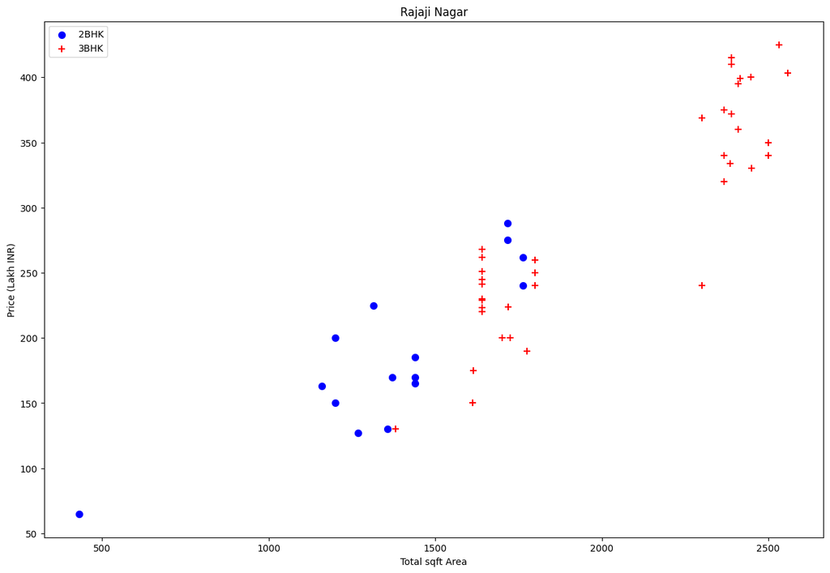

```python
plot_scatter_plot(df6, 'Rajaji Nagar')
```

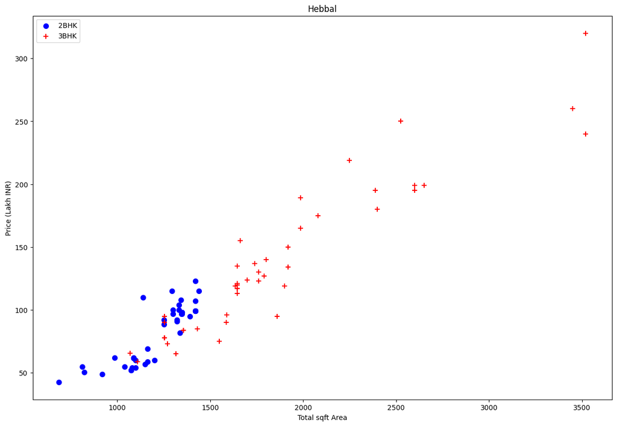

```python
plot_scatter_plot(df6, 'Hebbal')
```

**The above plot shows that there are few observation which got higher price of 2bhk than 3bhk for the same location. To correct this issue, we have to remove those observations where the price of smaller bhk is greater for the same location.**

```python
# Defining function for removing other outliers

def remove_bhk_outliers(df):
    exclude_indices = np.array([])
    for location, location_df in df.groupby('location'):
        bhk_stats = {}
        for bhk, bhk_df in location_df.groupby('bhk'):
            bhk_stats[bhk] = {
                'mean': np.mean(bhk_df.price_per_sqft),
                'std': np.std(bhk_df.price_per_sqft),
                'count': bhk_df.shape[0]
            }
        for bhk, bhk_df in location_df.groupby('bhk'):
            stats = bhk_stats.get(bhk-1)
            if stats and stats['count']>5:
                exclude_indices = np.append(exclude_indices,
                                            bhk_df[bhk_df.price_per_sqft<(stats['mean'])].index.values)
    return df.drop(exclude_indices,axis='index')
```

```python
df7 = df6.copy()
df7 = remove_bhk_outliers(df6)
df7.shape
```

```
(7597, 7)
```

**Again visualize to observe outliers.**

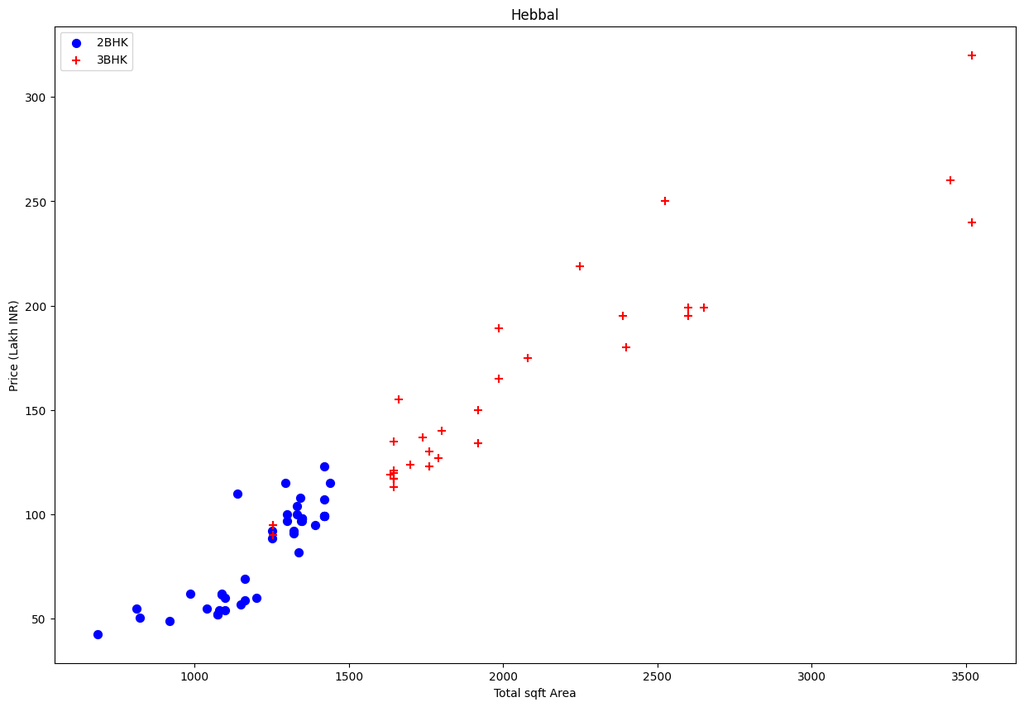

```python
plot_scatter_plot(df7, 'Hebbal')
```

**This shows that the outliers have been removed to a great extend.**

## Using 'Bathroom' feature

```python
df7.bath.unique()
```

```
array([ 4.,  3.,  6.,  2.,  5.,  1.,  8.,  7.,  9., 12., 10., 27., 16.,
       13.])
```

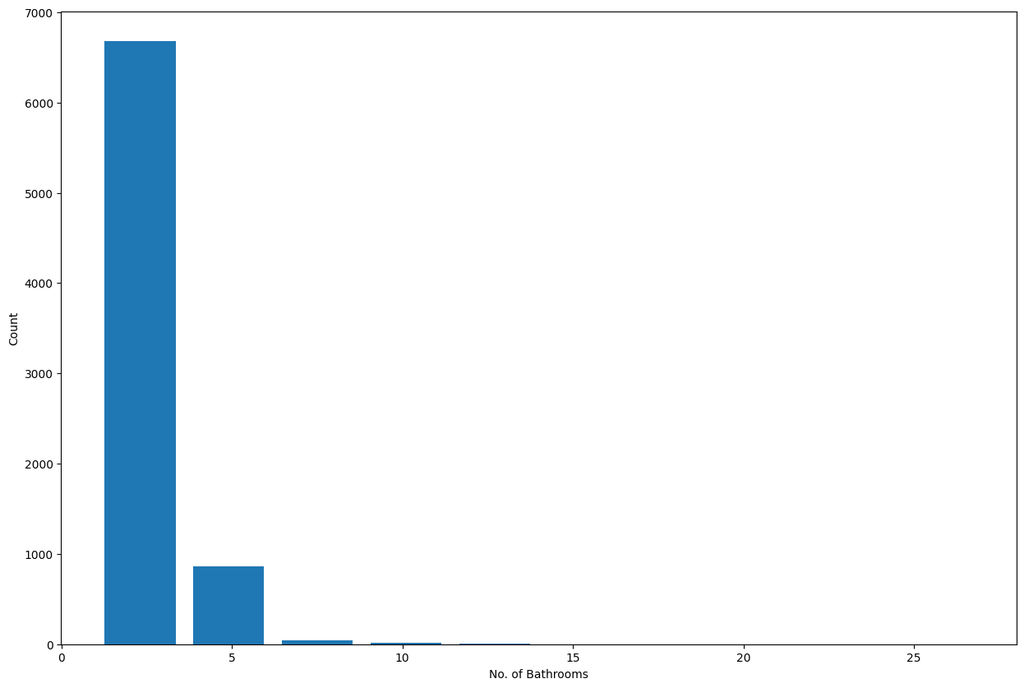

```python
plt.hist(df7.bath, rwidth=0.8)
plt.xlabel('No. of Bathrooms')
plt.ylabel('Count')
```

```python
# Checking observations with having more than 10 bathrooms

df7[df7.bath > 10]
```

|  | location | size | total_sqft | bath | price | bhk | price_per_sqft |
| --- | --- | --- | --- | --- | --- | --- | --- |
| 5482 | Neeladri Nagar | 10 BHK | 4000.0 | 12.0 | 160.0 | 10 | 4000.000000 |
| 8559 | other | 27 BHK | 8000.0 | 27.0 | 230.0 | 27 | 2875.000000 |
| 8898 | other | 16 BHK | 10000.0 | 16.0 | 550.0 | 16 | 5500.000000 |
| 9674 | other | 11 BHK | 6000.0 | 12.0 | 150.0 | 11 | 2500.000000 |
| 10014 | other | 13 BHK | 5425.0 | 13.0 | 275.0 | 13 | 5069.124424 |

```python
# Checking observation which have 2 more bath than the number of rooms they have

df7[df7.bath > (df7.bhk + 2)]
```

|  | location | size | total_sqft | bath | price | bhk | price_per_sqft |
| --- | --- | --- | --- | --- | --- | --- | --- |
| 1580 | Chamrajpet | 6 Bedroom | 1500.0 | 9.0 | 230.0 | 6 | 15333.333333 |
| 1716 | Chikkabanavar | 4 Bedroom | 2460.0 | 7.0 | 80.0 | 4 | 3252.032520 |
| 5442 | Nagasandra | 4 Bedroom | 7000.0 | 8.0 | 450.0 | 4 | 6428.571429 |
| 6965 | Thanisandra | 3 BHK | 1806.0 | 6.0 | 116.0 | 3 | 6423.034330 |
| 8729 | other | 6 BHK | 11338.0 | 9.0 | 1000.0 | 6 | 8819.897689 |
| 10028 | other | 6 Bedroom | 1200.0 | 9.0 | 122.0 | 6 | 10166.666667 |

**With little bit of ground information and basic common sense one can think that there is unusual of having bathrooms 2 more than bedrooms one has, even after inculding one bathfor guest. So, the better idea is to remove those observations which has more than 2 'bath' than the bedrooms it has, as they might be outliers.**

```python
df8 = df7[df7.bath < (df7.bhk + 2)]
df8.shape
```

```
(7516, 7)
```

# Giving Dummy variable to each 'location'

Here we deal with categorical data, and we:

- Convert categorical location data into numerical values using one-hot encoding.
- Removed 'other' category from this avoiding **'Dummy Variable Trap'**.

```python
dummies = pd.get_dummies(df8.location).astype(int)
dummies.head()
```

|  | 1st Block Jayanagar | 1st Phase JP Nagar | 2nd Phase Judicial Layout | 2nd Stage Nagarbhavi | 5th Block Hbr Layout | 5th Phase JP Nagar | 6th Phase JP Nagar | 7th Phase JP Nagar | 8th Phase JP Nagar | 9th Phase JP Nagar | ... | Vishveshwarya Layout | Vishwapriya Layout | Vittasandra | Whitefield | Yelachenahalli | Yelahanka | Yelahanka New Town | Yelenahalli | Yeshwanthpur | other |
| --- | --- | --- | --- | --- | --- | --- | --- | --- | --- | --- | --- | --- | --- | --- | --- | --- | --- | --- | --- | --- | --- |
| 0 | 1 | 0 | 0 | 0 | 0 | 0 | 0 | 0 | 0 | 0 | ... | 0 | 0 | 0 | 0 | 0 | 0 | 0 | 0 | 0 | 0 |
| 1 | 1 | 0 | 0 | 0 | 0 | 0 | 0 | 0 | 0 | 0 | ... | 0 | 0 | 0 | 0 | 0 | 0 | 0 | 0 | 0 | 0 |
| 2 | 1 | 0 | 0 | 0 | 0 | 0 | 0 | 0 | 0 | 0 | ... | 0 | 0 | 0 | 0 | 0 | 0 | 0 | 0 | 0 | 0 |
| 3 | 1 | 0 | 0 | 0 | 0 | 0 | 0 | 0 | 0 | 0 | ... | 0 | 0 | 0 | 0 | 0 | 0 | 0 | 0 | 0 | 0 |
| 4 | 1 | 0 | 0 | 0 | 0 | 0 | 0 | 0 | 0 | 0 | ... | 0 | 0 | 0 | 0 | 0 | 0 | 0 | 0 | 0 | 0 |

5 rows × 241 columns

```python
df9 = pd.concat([df8, dummies.drop('other', axis=1)], axis=1)
df9.head()
```

|  | location | size | total_sqft | bath | price | bhk | price_per_sqft | 1st Block Jayanagar | 1st Phase JP Nagar | 2nd Phase Judicial Layout | ... | Vijayanagar | Vishveshwarya Layout | Vishwapriya Layout | Vittasandra | Whitefield | Yelachenahalli | Yelahanka | Yelahanka New Town | Yelenahalli | Yeshwanthpur |
| --- | --- | --- | --- | --- | --- | --- | --- | --- | --- | --- | --- | --- | --- | --- | --- | --- | --- | --- | --- | --- | --- |
| 0 | 1st Block Jayanagar | 4 BHK | 2850.0 | 4.0 | 428.0 | 4 | 15017.543860 | 1 | 0 | 0 | ... | 0 | 0 | 0 | 0 | 0 | 0 | 0 | 0 | 0 | 0 |
| 1 | 1st Block Jayanagar | 3 BHK | 1630.0 | 3.0 | 194.0 | 3 | 11901.840491 | 1 | 0 | 0 | ... | 0 | 0 | 0 | 0 | 0 | 0 | 0 | 0 | 0 | 0 |
| 2 | 1st Block Jayanagar | 6 BHK | 1200.0 | 6.0 | 125.0 | 6 | 10416.666667 | 1 | 0 | 0 | ... | 0 | 0 | 0 | 0 | 0 | 0 | 0 | 0 | 0 | 0 |
| 3 | 1st Block Jayanagar | 3 BHK | 1875.0 | 2.0 | 235.0 | 3 | 12533.333333 | 1 | 0 | 0 | ... | 0 | 0 | 0 | 0 | 0 | 0 | 0 | 0 | 0 | 0 |
| 4 | 1st Block Jayanagar | 3 BHK | 1200.0 | 2.0 | 130.0 | 3 | 10833.333333 | 1 | 0 | 0 | ... | 0 | 0 | 0 | 0 | 0 | 0 | 0 | 0 | 0 | 0 |

5 rows × 247 columns

# Dropping unwanted Variables

This is the last and crucial step before building model, as it ensures that only related variables are included in the model for prediction and unrelated variables must be removed.

```python
df10 = df9.drop(['location', 'size', 'price_per_sqft'], axis=1)
df10.head()
```

|  | total_sqft | bath | price | bhk | 1st Block Jayanagar | 1st Phase JP Nagar | 2nd Phase Judicial Layout | 2nd Stage Nagarbhavi | 5th Block Hbr Layout | 5th Phase JP Nagar | ... | Vijayanagar | Vishveshwarya Layout | Vishwapriya Layout | Vittasandra | Whitefield | Yelachenahalli | Yelahanka | Yelahanka New Town | Yelenahalli | Yeshwanthpur |
| --- | --- | --- | --- | --- | --- | --- | --- | --- | --- | --- | --- | --- | --- | --- | --- | --- | --- | --- | --- | --- | --- |
| 0 | 2850.0 | 4.0 | 428.0 | 4 | 1 | 0 | 0 | 0 | 0 | 0 | ... | 0 | 0 | 0 | 0 | 0 | 0 | 0 | 0 | 0 | 0 |
| 1 | 1630.0 | 3.0 | 194.0 | 3 | 1 | 0 | 0 | 0 | 0 | 0 | ... | 0 | 0 | 0 | 0 | 0 | 0 | 0 | 0 | 0 | 0 |
| 2 | 1200.0 | 6.0 | 125.0 | 6 | 1 | 0 | 0 | 0 | 0 | 0 | ... | 0 | 0 | 0 | 0 | 0 | 0 | 0 | 0 | 0 | 0 |
| 3 | 1875.0 | 2.0 | 235.0 | 3 | 1 | 0 | 0 | 0 | 0 | 0 | ... | 0 | 0 | 0 | 0 | 0 | 0 | 0 | 0 | 0 | 0 |
| 4 | 1200.0 | 2.0 | 130.0 | 3 | 1 | 0 | 0 | 0 | 0 | 0 | ... | 0 | 0 | 0 | 0 | 0 | 0 | 0 | 0 | 0 | 0 |

5 rows × 244 columns

# Building The Model

```python
df10.shape
```

```
(7516, 244)
```

```python
X = df10.drop(['price'], axis=1)
y = df10.price
```

```python
print(X.shape)
print(y.shape)
```

```
(7516, 243)
(7516,)
```

```python
from sklearn.model_selection import train_test_split

X_train, X_test, y_train, y_test = train_test_split(X, y, test_size=0.2, random_state=42)
```

```python
from sklearn.linear_model import LinearRegression

lr_clf = LinearRegression()
lr_clf.fit(X_train, y_train)
lr_clf.score(X_test, y_test)
```

```
0.8208710687366674
```

**We apply cross-validation to ensure the model generalizes well to unseen data.**

```python
from sklearn.model_selection import ShuffleSplit
from sklearn.model_selection import cross_val_score

cv = ShuffleSplit(n_splits=5, test_size=0.2, random_state=42)

cross_val_score(lr_clf, X, y, cv=cv)
```

```
array([0.82087107, 0.83760509, 0.81427653, 0.84878921, 0.84213636])
```

**This can be observed that for 5 iterations we are getting more than 80% accuracy. This is good but need to observe other models as well to find best one.**

## Model Selection & Training

We experiment with different regression models to determine the best-performing one using `GridSearchCV`. Models considered include:

- Linear Regression
- Lasso Regression
- Decision Tree Regressor

We define a function that tests multiple models and selects the one with the highest accuracy.

```python
from sklearn.model_selection import GridSearchCV

from sklearn.linear_model import Lasso
from sklearn.tree import DecisionTreeRegressor
from sklearn.pipeline import Pipeline
from sklearn.preprocessing import StandardScaler

def find_best_model_using_GridsearchCV(X, y):
    # Ensuring X is a DataFrame
    if not isinstance(X, pd.DataFrame):
        X = pd.DataFrame(X)

    # Normalization pipeline
    scaler = StandardScaler()

    algos = {
        'linear_regression': {
            'model' : Pipeline([
                ('scaler', scaler),
                ('regressor', LinearRegression())
            ]),
            'params' : {
                'regressor__fit_intercept': [True, False]
            }
        },
        'lasso': {
            'model' : Pipeline([
                ('scaler', scaler),
                ('regressor', Lasso())
            ]),
            'params' : {
                'regressor__alpha': [1, 2],
                'regressor__selection': ['random', 'cyclic']
            }
        },
        'decision_tree': {
            'model': Pipeline([
                ('scaler', scaler),
                ('regressor', DecisionTreeRegressor())
            ]),
            'params': {
                'regressor__criterion': ['squared_error', 'friedman_mse'],
                'regressor__splitter': ['best', 'random']
            }
        }
    }

    scores = []
    cv = ShuffleSplit(n_splits=5, test_size=0.2, random_state=42)

    for algo_name, config in algos.items():
        gs = GridSearchCV(config['model'], config['params'], cv=cv, return_train_score=False)
        gs.fit(X, y)
        scores.append({
            'model': algo_name,
            'best_score': gs.best_score_,
            'best_params': gs.best_params_
        })

    return pd.DataFrame(scores, columns=['model', 'best_score', 'best_params'])
```

```python
find_best_model_using_GridsearchCV(X, y)
```

|  | model | best_score | best_params |
| --- | --- | --- | --- |
| 0 | linear_regression | 0.832736 | {'regressor__fit_intercept': True} |
| 1 | lasso | 0.808946 | {'regressor__alpha': 1, 'regressor__selection'... |
| 2 | decision_tree | 0.729772 | {'regressor__criterion': 'squared_error', 'reg... |

**Observing the above results, we can say that the Linear Regression is giving the best result as compared to the Lasso Regressor and Decision Tree Regressor, as it is giving the highest best_score. Thus, we'll use the Linear Regression model.**

## House Price Prediction Function

We create a function `predict_price()` that takes user input (location, square footage, number of bedrooms, and bathrooms) and returns the estimated house price.

This allows users to get instant price estimates by entering relevant details.

```python
# Defining Function for predicting price

def predict_price(location, sqft, bhk, bath):
    x = np.zeros(len(X.columns))  # Ensure the same number of features

    x[0] = sqft
    x[1] = bhk
    x[2] = bath

    if location in X.columns:
        loc_index = np.where(X.columns == location)[0][0]
        x[loc_index] = 1

    x_df = pd.DataFrame([x], columns=X.columns)

    return lr_clf.predict(x_df)[0]
```

**Checking the developed model on few observation.**

```python
predict_price('1st Phase JP Nagar', 1000, 2, 2)
```

```
np.float64(79.05538148808806)
```

```python
predict_price('1st Phase JP Nagar', 1000, 3, 3)
```

```
np.float64(74.6168769884954)
```

```python
predict_price('Indira Nagar', 1000, 2, 2)
```

```
np.float64(176.36538295828439)
```

```python
predict_price('Indira Nagar', 1000, 3, 3)
```

```
np.float64(171.9268784586917)
```

# Exporting the tested model

```python
import pickle
with open('banglore_houses_price_model.pickle', 'wb') as f:
    pickle.dump(lr_clf, f)
```

# Conclusion & Future Work

### Key Takeaways:

✅ Data cleaning and preprocessing significantly impact model accuracy.

✅ Feature engineering helps improve predictive power.

✅ Different regression models have varying strengths—Linear Regression performed best for this dataset.

### Next Steps:

🚀 Experiment with more advanced models like Random Forest or XGBoost.

🚀 Deploy the model as a web application using Flask or Streamlit.

🚀 Enhance feature selection for improved accuracy.

# Final Thoughts

This project provides a hands-on approach to data science, from data cleaning to model deployment. By fine-tuning our approach, we can achieve better results and expand our application to real-world use cases.

### 📌 Connect & Explore More

If you found this project insightful, feel free to check it out on Kaggle & GitHub! 🚀